# USA SHOOTINGS

Details about this project can be found in the readme file

```r
getwd()
```

```
[1] "C:/Users/Michael/Documents/R Projects"
```

#### **import the required libraries**

```r
library(dplyr)
library(tidyr)
library(readr)
library(ggplot2)
library(lubridate)
library(lattice)

print("Setup Complete!")
```

```
[1] "Setup Complete!"
```

#### **Import the Data-set**

```r
filepath <- "F:/Data Science/My Datasets/USA_shootings.csv"
shootings <- read.csv(filepath)
print("Import Successful")
```

```
[1] "Import Successful"
```

# **EXPLORATORY DATA ANALYSIS**

```r
head(shootings)
```

|  | id | name | date | manner_of_death | armed | age | gender | race | city | state | signs_of_mental_illness | threat_level | flee | body_camera | arms_category |
| --- | --- | --- | --- | --- | --- | --- | --- | --- | --- | --- | --- | --- | --- | --- | --- |
| 1 | 3 | Tim Elliot | 2015-01-02 | shot | gun | 53 | M | Asian | Shelton | WA | True | attack | Not fleeing | False | Guns |
| 2 | 4 | Lewis Lee Lembke | 2015-01-02 | shot | gun | 47 | M | White | Aloha | OR | False | attack | Not fleeing | False | Guns |
| 3 | 5 | John Paul Quintero | 2015-01-03 | shot and Tasered | unarmed | 23 | M | Hispanic | Wichita | KS | False | other | Not fleeing | False | Unarmed |
| 4 | 8 | Matthew Hoffman | 2015-01-04 | shot | toy weapon | 32 | M | White | San Francisco | CA | True | attack | Not fleeing | False | Other unusual objects |
| 5 | 9 | Michael Rodriguez | 2015-01-04 | shot | nail gun | 39 | M | Hispanic | Evans | CO | False | attack | Not fleeing | False | Piercing objects |
| 6 | 11 | Kenneth Joe Brown | 2015-01-04 | shot | gun | 18 | M | White | Guthrie | OK | False | attack | Not fleeing | False | Guns |

```r
dim(shootings)
```

```
[1] 4895   15
```

#### **Addition of the Age group column**

```r
shootings <- shootings%>% mutate(Age_group = case_when(age > 0 & age <= 12 ~ "Child",
                                                                 age >= 13 & age <= 19 ~ "Teenager",
                                                                 age >= 20 & age <= 40 ~ "Young Adult",
                                                                 age >= 41 & age <= 65 ~ "Adult",
                                                                 age > 65 ~ "Senior"))
```

Now lets check if the column has been added

```r
head(shootings)
```

|  | id | name | date | manner_of_death | armed | age | gender | race | city | state | signs_of_mental_illness | threat_level | flee | body_camera | arms_category | Age_group |
| --- | --- | --- | --- | --- | --- | --- | --- | --- | --- | --- | --- | --- | --- | --- | --- | --- |
| 1 | 3 | Tim Elliot | 2015-01-02 | shot | gun | 53 | M | Asian | Shelton | WA | True | attack | Not fleeing | False | Guns | Adult |
| 2 | 4 | Lewis Lee Lembke | 2015-01-02 | shot | gun | 47 | M | White | Aloha | OR | False | attack | Not fleeing | False | Guns | Adult |
| 3 | 5 | John Paul Quintero | 2015-01-03 | shot and Tasered | unarmed | 23 | M | Hispanic | Wichita | KS | False | other | Not fleeing | False | Unarmed | Young Adult |
| 4 | 8 | Matthew Hoffman | 2015-01-04 | shot | toy weapon | 32 | M | White | San Francisco | CA | True | attack | Not fleeing | False | Other unusual objects | Young Adult |
| 5 | 9 | Michael Rodriguez | 2015-01-04 | shot | nail gun | 39 | M | Hispanic | Evans | CO | False | attack | Not fleeing | False | Piercing objects | Young Adult |
| 6 | 11 | Kenneth Joe Brown | 2015-01-04 | shot | gun | 18 | M | White | Guthrie | OK | False | attack | Not fleeing | False | Guns | Teenager |

Tadaaaaa>>>>

#### **Conversion of columns to appropriate classes**

```r
shootings$manner_of_death <- as.factor(shootings$manner_of_death)
shootings$armed <- as.factor(shootings$armed)
shootings$date <- ymd(shootings$date)
shootings$gender <- as.factor(shootings$gender)
shootings$race <- as.factor(shootings$race)
shootings$city <- as.factor(shootings$city)
shootings$state <- as.factor(shootings$state)
shootings$signs_of_mental_illness <- as.factor(shootings$signs_of_mental_illness)
shootings$threat_level <- as.factor(shootings$threat_level)
shootings$flee <- as.factor(shootings$flee)
shootings$body_camera <- as.factor(shootings$body_camera)
shootings$arms_category <- as.factor(shootings$arms_category)
```

Lets check if the classes of the columns have been changed

```r
head(shootings)
```

|  | id | name | date | manner_of_death | armed | age | gender | race | city | state | signs_of_mental_illness | threat_level | flee | body_camera | arms_category | Age_group |
| --- | --- | --- | --- | --- | --- | --- | --- | --- | --- | --- | --- | --- | --- | --- | --- | --- |
| 1 | 3 | Tim Elliot | 2015-01-02 | shot | gun | 53 | M | Asian | Shelton | WA | True | attack | Not fleeing | False | Guns | Adult |
| 2 | 4 | Lewis Lee Lembke | 2015-01-02 | shot | gun | 47 | M | White | Aloha | OR | False | attack | Not fleeing | False | Guns | Adult |
| 3 | 5 | John Paul Quintero | 2015-01-03 | shot and Tasered | unarmed | 23 | M | Hispanic | Wichita | KS | False | other | Not fleeing | False | Unarmed | Young Adult |
| 4 | 8 | Matthew Hoffman | 2015-01-04 | shot | toy weapon | 32 | M | White | San Francisco | CA | True | attack | Not fleeing | False | Other unusual objects | Young Adult |
| 5 | 9 | Michael Rodriguez | 2015-01-04 | shot | nail gun | 39 | M | Hispanic | Evans | CO | False | attack | Not fleeing | False | Piercing objects | Young Adult |
| 6 | 11 | Kenneth Joe Brown | 2015-01-04 | shot | gun | 18 | M | White | Guthrie | OK | False | attack | Not fleeing | False | Guns | Teenager |

## **Manner Of Death**

```r
mann.tbl <- shootings %>% group_by(manner_of_death) %>% summarize(`Death Toll` = n())
mann.tbl <- rename(mann.tbl, "Manner of Death" = "manner_of_death")
mann.tbl
```

| Manner of Death | Death Toll |
| --- | --- |
| shot | 4647 |
| shot and Tasered | 248 |

- As seen above, only few of the victims were shot and tasered

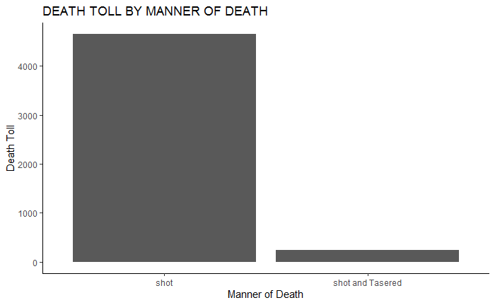

```r
g <- ggplot(mann.tbl, aes(x = `Manner of Death`, y = `Death Toll`))
g + geom_bar(stat = "identity") + ggtitle("DEATH TOLL BY MANNER OF DEATH") + theme_classic()
```

- The chart above clearly shows the wide difference between individuals that were only shot and individuals that were shot and tasered

## **Armed**

```r
armed_grp <- table(shootings$armed)
armed_grp <- as.data.frame(armed_grp)
armed_grp <- rename(armed_grp, "Weapons" = "Var1", "Victims Count" = "Freq")
#new_column_name = old_column_name
armed_grp <- armed_grp %>% arrange(desc(`Victims Count`)) %>% mutate(Percentage = (`Victims Count`/4895) * 100)
armed_grp$Percentage <- round(armed_grp$Percentage, digits = 1)
armed_grp
```

| Weapons | Victims Count | Percentage |
| --- | --- | --- |
| gun | 2755 | 56.3 |
| knife | 708 | 14.5 |
| unknown | 418 | 8.5 |
| unarmed | 348 | 7.1 |
| toy weapon | 171 | 3.5 |
| vehicle | 120 | 2.5 |
| machete | 39 | 0.8 |
| Taser | 24 | 0.5 |
| sword | 22 | 0.4 |
| ax | 21 | 0.4 |

[output cut: 79 more lines]

Lets move further to uncover more insights

```r
guns <- subset(shootings, armed == "gun")
gun.grp <- guns%>% select(race) %>% group_by(race) %>% summarize(`Owned Gun` = n()) %>% arrange(desc(`Owned Gun`))
print(gun.grp)
```

| race | Owned Gun |
| --- | --- |
| White | 1451 |
| Black | 762 |
| Hispanic | 447 |
| Native | 41 |
| Asian | 35 |
| Other | 19 |

- More white victims owned guns more than any other race in this data set

## **Gender and Race**

```r
gr_grp <- shootings %>% select(race, gender) %>% group_by(race, gender) %>% summarize(`Victim Counts` = n())
gr_grp
```

| race | gender | Victim Counts |
| --- | --- | --- |
| Asian | F | 4 |
| Asian | M | 89 |
| Black | F | 47 |
| Black | M | 1251 |
| Hispanic | F | 26 |
| Hispanic | M | 876 |
| Native | F | 5 |
| Native | M | 73 |
| Other | F | 4 |
| Other | M | 44 |

[output cut: 2 more lines]

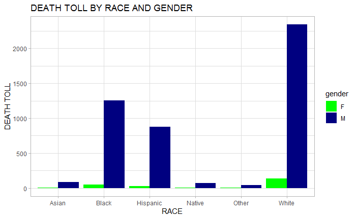

```r
g <- ggplot(gr_grp, aes(x = race, y = `Victim Counts`))
g + geom_bar(aes(fill = gender), stat = "identity", position = position_dodge()) + xlab("RACE") + ylab("DEATH TOLL") + ggtitle("DEATH TOLL BY RACE AND GENDER") + scale_fill_manual(values = c("green", "navy blue")) + theme_light()
```

- It ia evident that police shot more white men and women than any other race as opposed to popular belief that blacks have been the more victims.

Lets dive deeper

## **City**

```r
city.grp <- shootings %>% select(city) %>% group_by(city) %>% summarize(`Death Toll` = n()) %>% arrange(desc(`Death Toll`)) %>% mutate(Percentage = (`Death Toll`/4895) *100)
city.grp$Percentage <- round(city.grp$Percentage, digits = 1)
city.grp
```

| city | Death Toll | Percentage |
| --- | --- | --- |
| Los Angeles | 78 | 1.6 |
| Phoenix | 66 | 1.3 |
| Houston | 51 | 1.0 |
| Las Vegas | 41 | 0.8 |
| San Antonio | 40 | 0.8 |
| Chicago | 38 | 0.8 |
| Columbus | 36 | 0.7 |
| Albuquerque | 32 | 0.7 |
| Jacksonville | 31 | 0.6 |
| Oklahoma City | 30 | 0.6 |

[output cut: 990 more lines]

## **State**

```r
states_grp <- shootings %>% select(state) %>% group_by(state) %>% summarize(`Death Toll` = n()) %>% arrange(desc(`Death Toll`)) %>% mutate(Percentage = (`Death Toll`/4895) * 100)
states_grp$Percentage <- round(states_grp$Percentage, digits = 1)

states_grp
```

| state | Death Toll | Percentage |
| --- | --- | --- |
| CA | 701 | 14.3 |
| TX | 426 | 8.7 |
| FL | 324 | 6.6 |
| AZ | 222 | 4.5 |
| CO | 168 | 3.4 |
| GA | 161 | 3.3 |
| OK | 151 | 3.1 |
| NC | 148 | 3.0 |
| OH | 146 | 3.0 |
| WA | 126 | 2.6 |

[output cut: 41 more lines]

- As seen above the top three states with the highest Death toll are California, Texas and Florida

## **Mental Status**

```r
mental.illness <-table(shootings$signs_of_mental_illness)
mental.illness
```

```
False  True
 3792  1103
```

- Most of the victims didn’t show signs mental illnesses

```r
ment <- data.frame(`Mental status` = c("No mental Illness", "Has mental illness"), `Death toll` = c(3792, 1103))
ment
```

| Mental.status | Death.toll |
| --- | --- |
| No mental Illness | 3792 |
| Has mental illness | 1103 |

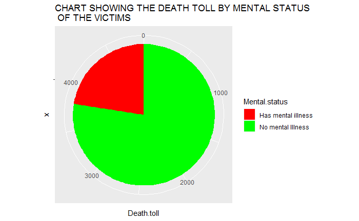

```r
g <- ggplot(ment, aes(x = "", y = Death.toll, fill = Mental.status))
bar <- g + geom_bar(stat = "identity")
bar + coord_polar("y", start = 0) + scale_fill_manual(values = c("red", "green")) +ggtitle("CHART SHOWING THE DEATH TOLL BY MENTAL STATUS \n OF THE VICTIMS")
```

## **Threat level**

```r
threat <- shootings %>% select(threat_level, race) %>%group_by(race,threat_level) %>%  summarize(Death.toll = n()) %>% arrange(desc(Death.toll))
threat <- rename(threat, "Threat level" = "threat_level")
threat
```

| race | Threat level | Death.toll |
| --- | --- | --- |
| White | attack | 1640 |
| Black | attack | 873 |
| White | other | 743 |
| Hispanic | attack | 521 |
| Black | other | 364 |
| Hispanic | other | 333 |
| White | undetermined | 93 |
| Black | undetermined | 61 |
| Asian | attack | 51 |
| Hispanic | undetermined | 48 |

[output cut: 7 more lines]

- Majority of the victims were a potential threat to the police hence they were shot

Lets see how the death toll by threat level regarding race in a chart below

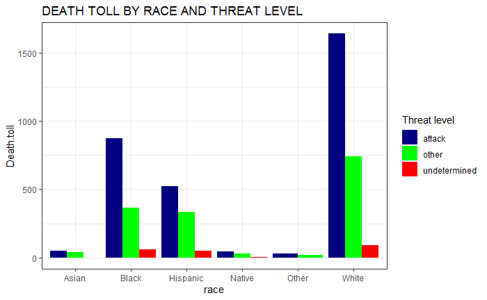

```r
g <- ggplot(threat, aes(x = race, y = Death.toll, fill = `Threat level`))
g + geom_bar(stat = "identity", position = position_dodge()) + scale_fill_manual(values = c("navy blue", "green", "red")) + ggtitle("DEATH TOLL BY RACE AND THREAT LEVEL") + theme_bw()
```

- The white race leads in all categories

## **Was the Victim Fleeing**

```r
flee <- shootings %>% select(flee) %>% group_by(flee) %>% summarize(`Death toll` = n()) %>% arrange(desc(`Death toll`))
flee <- rename(flee, "Fleeing status" = "flee")
flee
```

| Fleeing status | Death toll |
| --- | --- |
| Not fleeing | 3073 |
| Car | 820 |
| Foot | 642 |
| Other | 360 |

- Most of the victims were not fleeing

## **Was the incident recorded on body camera**

```r
camera <- shootings %>% select(body_camera) %>% group_by(body_camera) %>% summarize(`Death toll` = n()) %>% arrange(desc(`Death toll`))
camera
```

| body_camera | Death toll |
| --- | --- |
| False | 4317 |
| True | 578 |

- Most of the incidents were not recorded on body camera

## **Arms Category**

```r
arms <- shootings %>% select(arms_category, armed) %>% group_by(arms_category, armed) %>% summarize(`Death toll` = n()) %>% arrange(desc(`Death toll`))
arms <- rename(arms, "Weapon"= "armed")
arms
```

| arms_category | Weapon | Death toll |
| --- | --- | --- |
| Guns | gun | 2755 |
| Sharp objects | knife | 708 |
| Unknown | unknown | 418 |
| Unarmed | unarmed | 348 |
| Other unusual objects | toy weapon | 171 |
| Vehicles | vehicle | 120 |
| Sharp objects | machete | 39 |
| Electrical devices | Taser | 24 |
| Sharp objects | sword | 22 |
| Blunt instruments | ax | 21 |

[output cut: 79 more lines]

```r
age_group <- shootings %>% select(Age_group, race, gender) %>% group_by(Age_group, gender, race) %>% summarize(`Death toll` = n())
age_group
```

| Age_group | gender | race | Death toll |
| --- | --- | --- | --- |
| Adult | F | Asian | 1 |
| Adult | F | Black | 9 |
| Adult | F | Hispanic | 3 |
| Adult | F | Other | 1 |
| Adult | F | White | 58 |
| Adult | M | Asian | 30 |
| Adult | M | Black | 242 |
| Adult | M | Hispanic | 192 |
| Adult | M | Native | 12 |
| Adult | M | Other | 10 |

[output cut: 28 more lines]

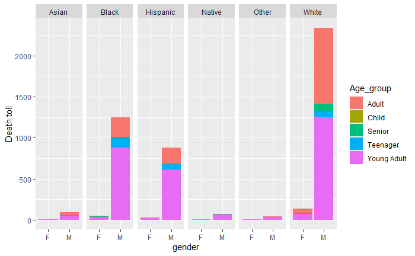

```r
g <- ggplot(age_group, aes(x = gender, y = `Death toll`, fill = Age_group))
g + geom_bar(stat = "identity", position = position_stack()) + facet_grid(. ~ race)
```